# project_greven

Jean-Paul Greven

1/9/2022

```r
# Importing data
df_killings <- readr::read_csv("PoliceKillingsUS.csv")
df_income <- readr::read_csv("MedianHouseholdIncome2015.csv")
df_race <- readr::read_csv("ShareRaceByCity.csv")
df_education <- readr::read_csv("PercentOver25CompletedHighSchool.csv")
```

```r
library(tidyverse)
library(ggplot2)
library(ggpubr)
library(cowplot)
library(broom)
```

# Dataset presentation

I will use the fatal police shootings in the US data. It comprises 5 datasets, of which 4 will be used during this project. The first section shall present those datasets, the second will be a first visualization of elements from the main dataset : “PoliceKillingsUS.csv”. The second section will try to link the main dataset to the race share. Finally, the last section will link income and education to the police killings location.

Since the authors for the main and side datasets are different, the main challenge of this project will consist in manipulating the data to allow a neat visualization between the main dataset and the three other ones. Thus a significant part of the code is Dplyr commands to then be able to use ggplot efficiently.

Let’s have a glance at the datasets:

```r
df_killings %>% str()
```

```
## spec_tbl_df [2,535 x 14] (S3: spec_tbl_df/tbl_df/tbl/data.frame)
##  $ id                     : num [1:2535] 3 4 5 8 9 11 13 15 16 17 ...
##  $ name                   : chr [1:2535] "Tim Elliot" "Lewis Lee Lembke" "John Paul Quintero" "Matthew Hoffman" ...
##  $ date                   : chr [1:2535] "02/01/15" "02/01/15" "03/01/15" "04/01/15" ...
##  $ manner_of_death        : chr [1:2535] "shot" "shot" "shot and Tasered" "shot" ...
##  $ armed                  : chr [1:2535] "gun" "gun" "unarmed" "toy weapon" ...
##  $ age                    : num [1:2535] 53 47 23 32 39 18 22 35 34 47 ...
##  $ gender                 : chr [1:2535] "M" "M" "M" "M" ...
##  $ race                   : chr [1:2535] "A" "W" "H" "W" ...
##  $ city                   : chr [1:2535] "Shelton" "Aloha" "Wichita" "San Francisco" ...
##  $ state                  : chr [1:2535] "WA" "OR" "KS" "CA" ...
##  $ signs_of_mental_illness: logi [1:2535] TRUE FALSE FALSE TRUE FALSE FALSE ...
##  $ threat_level           : chr [1:2535] "attack" "attack" "other" "attack" ...
##  $ flee                   : chr [1:2535] "Not fleeing" "Not fleeing" "Not fleeing" "Not fleeing" ...
##  $ body_camera            : logi [1:2535] FALSE FALSE FALSE FALSE FALSE FALSE ...
##  - attr(*, "spec")=
##   .. cols(
##   ..   id = col_double(),
##   ..   name = col_character(),
##   ..   date = col_character(),
##   ..   manner_of_death = col_character(),
##   ..   armed = col_character(),
##   ..   age = col_double(),
##   ..   gender = col_character(),
##   ..   race = col_character(),
##   ..   city = col_character(),
##   ..   state = col_character(),
##   ..   signs_of_mental_illness = col_logical(),
##   ..   threat_level = col_character(),
##   ..   flee = col_character(),
##   ..   body_camera = col_logical()
##   .. )
```

```r
df_income %>% str()
```

```
## spec_tbl_df [29,322 x 3] (S3: spec_tbl_df/tbl_df/tbl/data.frame)
##  $ Geographic Area: chr [1:29322] "AL" "AL" "AL" "AL" ...
##  $ City           : chr [1:29322] "Abanda CDP" "Abbeville city" "Adamsville city" "Addison town" ...
##  $ Median Income  : chr [1:29322] "11207" "25615" "42575" "37083" ...
##  - attr(*, "spec")=
##   .. cols(
##   ..   `Geographic Area` = col_character(),
##   ..   City = col_character(),
##   ..   `Median Income` = col_character()
##   .. )
```

```r
df_race %>% str()
```

```
## spec_tbl_df [29,268 x 7] (S3: spec_tbl_df/tbl_df/tbl/data.frame)
##  $ Geographic area      : chr [1:29268] "AL" "AL" "AL" "AL" ...
##  $ City                 : chr [1:29268] "Abanda CDP" "Abbeville city" "Adamsville city" "Addison town" ...
##  $ share_white          : chr [1:29268] "67.2" "54.4" "52.3" "99.1" ...
##  $ share_black          : chr [1:29268] "30.2" "41.4" "44.9" "0.1" ...
##  $ share_native_american: chr [1:29268] "0" "0.1" "0.5" "0" ...
##  $ share_asian          : chr [1:29268] "0" "1" "0.3" "0.1" ...
##  $ share_hispanic       : chr [1:29268] "1.6" "3.1" "2.3" "0.4" ...
##  - attr(*, "spec")=
##   .. cols(
##   ..   `Geographic area` = col_character(),
##   ..   City = col_character(),
##   ..   share_white = col_character(),
##   ..   share_black = col_character(),
##   ..   share_native_american = col_character(),
##   ..   share_asian = col_character(),
##   ..   share_hispanic = col_character()
##   .. )
```

```r
df_education %>% str()
```

```
## spec_tbl_df [29,329 x 3] (S3: spec_tbl_df/tbl_df/tbl/data.frame)
##  $ Geographic Area     : chr [1:29329] "AL" "AL" "AL" "AL" ...
##  $ City                : chr [1:29329] "Abanda CDP" "Abbeville city" "Adamsville city" "Addison town" ...
##  $ percent_completed_hs: chr [1:29329] "21.2" "69.1" "78.9" "81.4" ...
##  - attr(*, "spec")=
##   .. cols(
##   ..   `Geographic Area` = col_character(),
##   ..   City = col_character(),
##   ..   percent_completed_hs = col_character()
##   .. )
```

# Sign of mental illness during killings relation to sex and age

First, I will navigate the main dataset and try to visualize links between the sign of mental illness, sex and age.

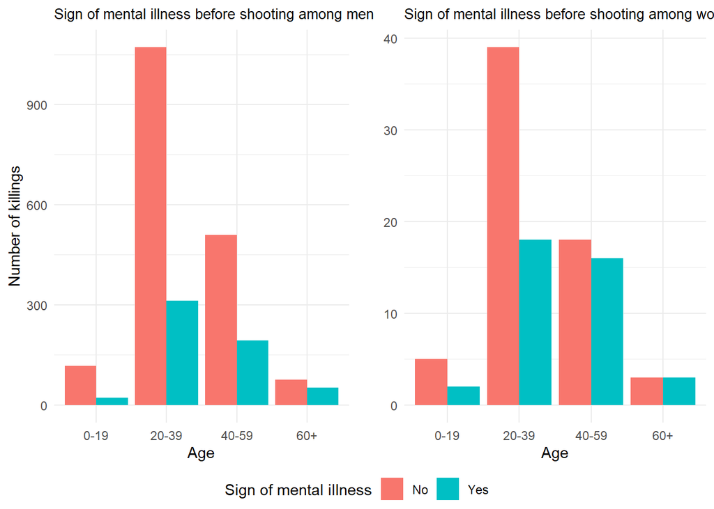

```r
  p1 <- df_killings %>%
  select(age,gender,signs_of_mental_illness) %>%
  drop_na() %>%
  filter(gender == "M") %>%
  mutate_at("age", as.numeric)%>%
  mutate(agegroup = case_when(age >= 60   ~ '60+',
                              age >= 40  & age <= 59 ~ '40-59',
                              age >= 20  & age <= 39 ~ '20-39',
                              age >= 0  & age <= 19 ~ '0-19',))%>%
  ggplot()+
  geom_bar(aes(x=agegroup,fill=factor(signs_of_mental_illness)),position = position_dodge(preserve = 'single'))+
  labs(y="Number of killings",x="Age", title = "Sign of mental illness before shooting among men")+
  scale_fill_discrete(name = "Sign of mental illness", labels = c("No", "Yes"))+
  theme_minimal()+
  theme(plot.title = element_text(size=10))


  p2 <- df_killings %>%
  select(age,gender,signs_of_mental_illness) %>%
  drop_na() %>%
  filter(gender == "F") %>%
  mutate_at("age", as.numeric)%>%
  mutate(agegroup = case_when(age >= 60   ~ '60+',
                              age >= 40  & age <= 59 ~ '40-59',
                              age >= 20  & age <= 39 ~ '20-39',
                              age >= 0  & age <= 19 ~ '0-19',))%>%
  ggplot()+
  geom_bar(aes(x=agegroup,fill=factor(signs_of_mental_illness)),position = position_dodge(preserve = 'single'))+
  labs(y="",x="Age", title = "Sign of mental illness before shooting among women")+
  scale_fill_discrete(name = "Sign of mental illness", labels = c("No", "Yes"))+
  theme_minimal()+
  theme(plot.title = element_text(size=10))


  ggarrange(p1, p2, common.legend = TRUE, legend="bottom")
```

Even if the number of fatal shootings involving women is smaller, we remark that the sign of mental illness is generally more present for them than men, for all age groups. We also remark that those signs are more present with age.

# Killings and Race by state

The first section aims to visualize the differences between the race shares by state and race shares in the fatal police shootings that occurred in those states. I shall first transform the city data to state data and plot it for each state. The second part will consist in extracting the relevant data from the police killings dataset, manipulate it in order to have a similar plot (it is not the same method since I have to extract shares from raw data). Finally, the goal of this section is to optimally combine those plots to visualize how race impacts fatal police shootings.To do so, I will compare the five states where most of the shootings happened.

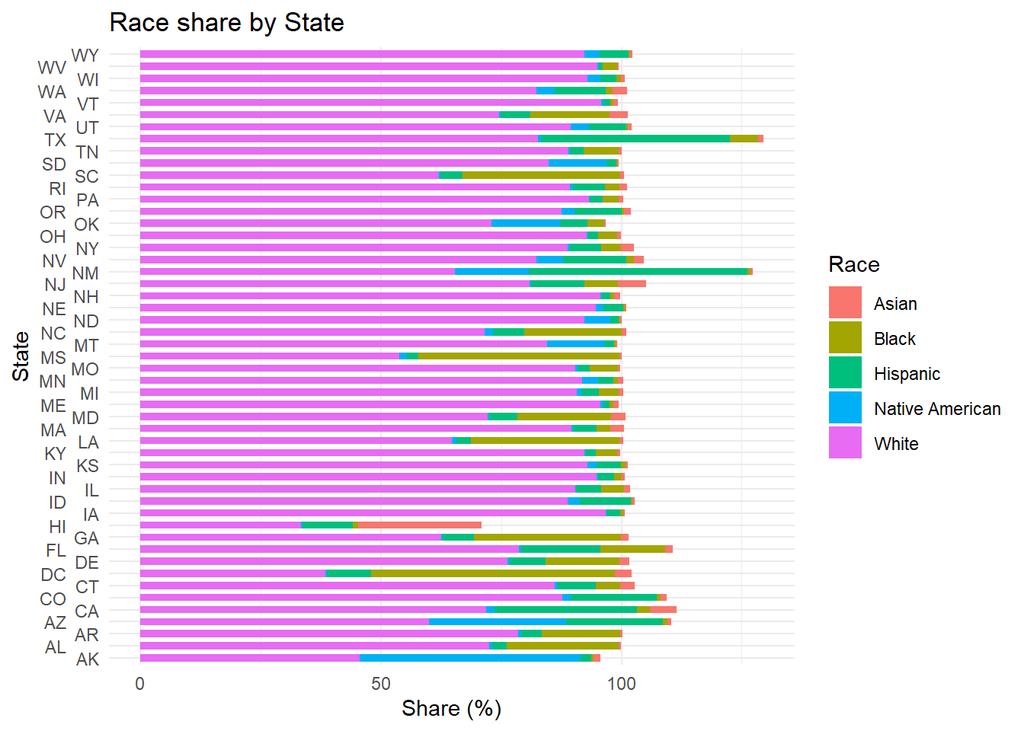

```r
# Cleaning the dataset (removing missing values and setting the shares to numeric)

share_races <- c("share_white", "share_black", "share_asian", "share_hispanic", "share_native_american")

df_race_clean <- df_race %>%
  filter(share_white != "(X)") %>% # removing missing data
  mutate(across(all_of(share_races), as.numeric)) # switching to numeric

# Aggregating to obtain the share by state

df_states_race <- df_race_clean %>%
  group_by(`Geographic area`) %>%
  summarise(across(share_races, mean))

# plot

df_states_race %>%
  pivot_longer(!`Geographic area`, names_to = "race_share", values_to = "share") %>%
  ggplot(aes(x=`Geographic area`,y=share,fill=race_share))+
  geom_col(width = 0.6)+
  coord_flip()+
  labs(x="State",y="Share (%)", title = "Race share by State")+
  scale_fill_discrete(name = "Race", labels = c("Asian", "Black", "Hispanic", "Native American", "White"))+
  scale_x_discrete(guide = guide_axis(n.dodge=2))+
  theme_minimal()
```

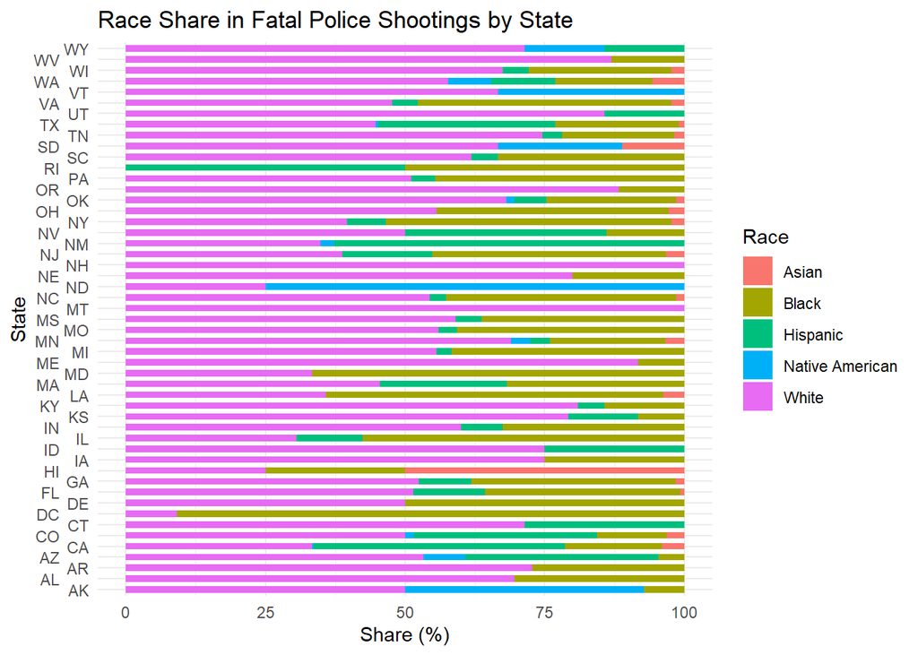

```r
# Extracting the race share from the data

df_killings %>%
  filter(race != 'O') %>% # Dropping the "other" value for race
  drop_na(race) %>%
  select(race,state)%>%
  group_by(race,state)%>%
  tally() %>% # Manipulations to have "plotable" data
  group_by(state)%>%
  mutate(total = sum(n), share = 100*n/total) %>% # Transforming count to share
  ggplot(aes(x=state,y=share,fill=race))+
  geom_col(width = 0.6)+
  coord_flip()+
  labs(x="State",y="Share (%)", title = "Race Share in Fatal Police Shootings by State")+
  scale_fill_discrete(name = "Race", labels = c("Asian", "Black", "Hispanic", "Native American", "White"))+
  scale_x_discrete(guide = guide_axis(n.dodge=2))+
  theme_minimal()
```

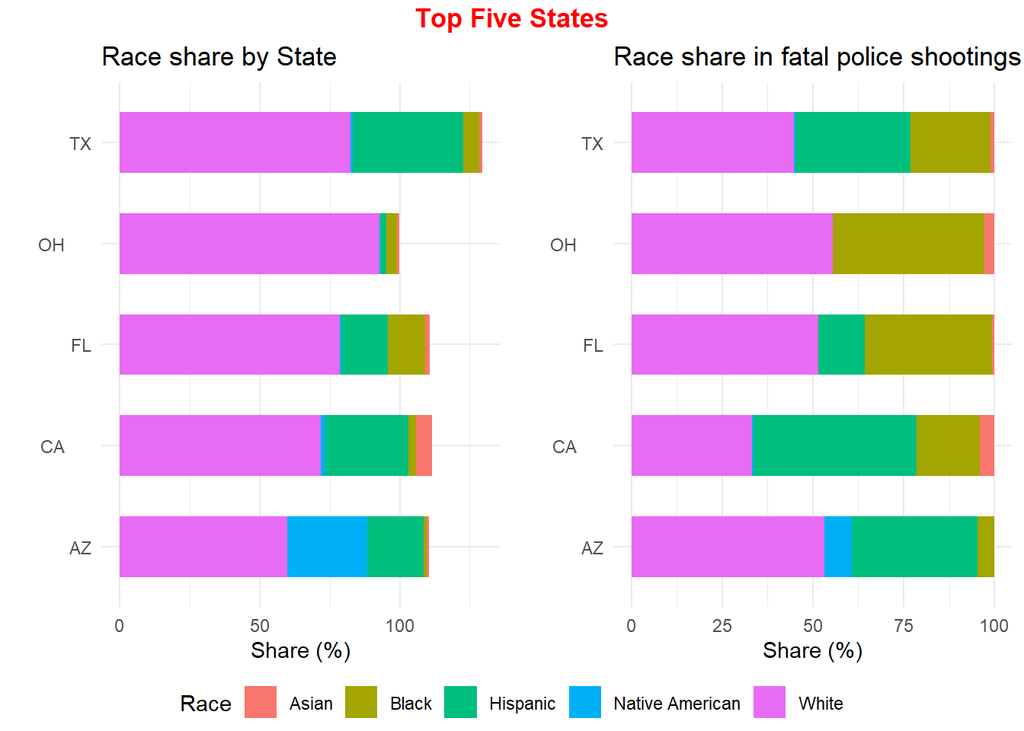

```r
# Final plot

## Isolating the top 5 states in the killing dataset

top5 <- df_killings %>%
  drop_na(race) %>%
  count(state)%>%
  slice_max(n, n=5) %>%
  pull(state)


p2 <- df_killings %>%
  filter(state %in% top5, race != 'O') %>% #Taking top 5, dropping the "other" value for race
  drop_na(race) %>%
  select(race,state)%>%
  group_by(race,state)%>%
  tally() %>% # Manipulation to have plotable data
  group_by(state)%>%
  mutate(total = sum(n), share = 100*n/total) %>% # Transforming count to share
  ggplot(aes(x=state,y=share,fill=race))+
  geom_col(width = 0.6)+
  coord_flip()+
  labs(x="",y="Share (%)", title = "Race share in fatal police shootings")+
  scale_fill_discrete(name = "Race", labels = c("Asian", "Black", "Hispanic", "Native American", "White"))+
  scale_x_discrete(guide = guide_axis(n.dodge=2))+
  theme(plot.title = element_text(size=10))+
  theme_minimal()



p1 <- df_states_race %>%
  filter(`Geographic area` %in% top5)%>%
  pivot_longer(!`Geographic area`, names_to = "race_share", values_to = "share") %>%
  ggplot(aes(x=`Geographic area`,y=share,fill=race_share))+
  geom_col(width = 0.6)+
  coord_flip()+
  labs(x="",y="Share (%)", title = "Race share by State")+
  scale_fill_discrete(name = "Race", labels = c("Asian", "Black", "Hispanic", "Native American", "White"))+
  scale_x_discrete(guide = guide_axis(n.dodge=2))+
  theme(plot.title = element_text(size=10))+
  theme_minimal()

effort2 <- ggarrange(p1, p2, common.legend = TRUE, legend="bottom")
annotate_figure(effort2, top = text_grob("Top Five States",
               color = "red", face = "bold", size = 13))
```

We can directly observe that Black people are a lot more likely to be victim of a police shooting in those five states. We also note that in Arizona and California, Hispanic people are also more likely to die in such circumstances. This however seems not to be true for the three other states.

# Education & Income trend by city of killing

In this section I will try to visualize if income or education plays a role in the location of fatal shootings. First I will plot the city distribution by both income and education. Education is evaluated by the percentage of people over 25 that have a high school degree, while income will be assessed by the median annual household income of the city.

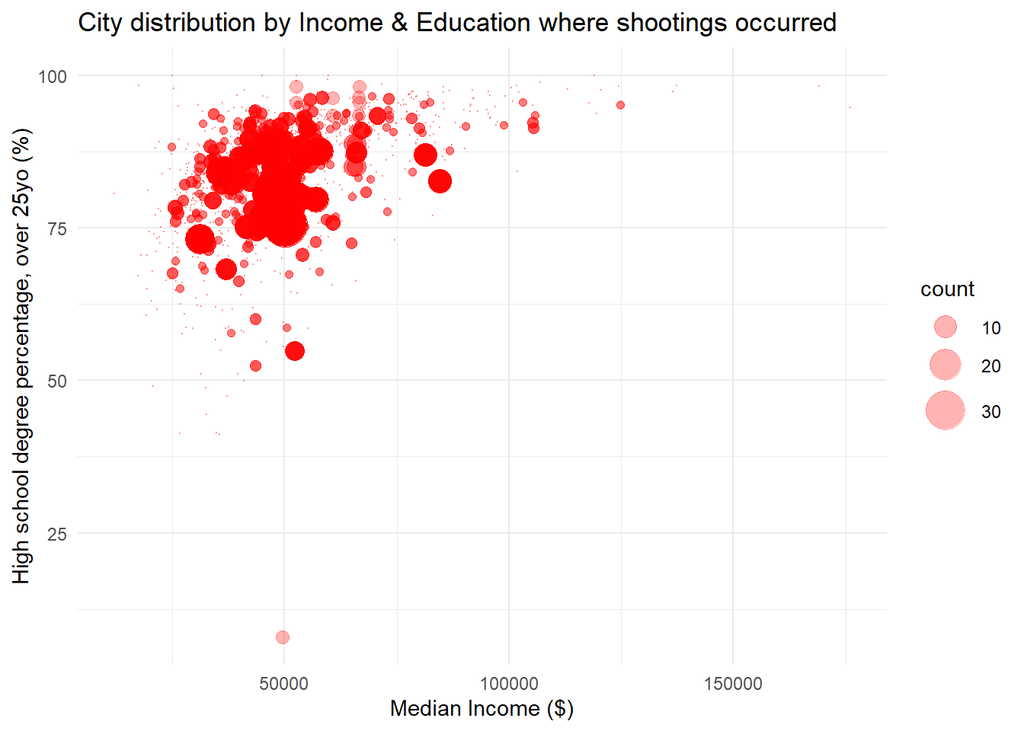

```r
df_temp1 <- rename(df_education, education = 3, city = 2, state = 1)%>%
mutate(city = word(city , 1  , -2))
df_temp2 <-  rename(df_income,income = 3, city = 2, state = 1)%>%
mutate(city = word(city , 1  , -2))

shooting_cities <- df_temp1 %>%
  inner_join(df_temp2, by = c("city","state")) %>%
  inner_join(df_killings, by = c("city","state")) %>%
  select(state,city,education,income)%>%
  group_by(state,city) %>%
  mutate(count = n()) %>%
  unite("city",state:city, remove = TRUE)%>%
  drop_na()%>%
  filter(income != "(X)", education != "(X)",income != "-", education != "-")


shooting_cities  %>%
  mutate_at(c("education","income"),as.numeric)%>%
  ggplot(aes(x=income,y=education))+
  geom_jitter(aes(size = count), alpha = 0.3,color = "red") +
  scale_size(range = c(0, 10))+
  theme(axis.text.x=element_blank(),axis.text.y=element_blank())+
  theme_minimal()+
  labs(x="Median Income ($)",y="High school degree percentage, over 25yo (%)", title = "City distribution by Income & Education where shootings occurred")
```

Now the same for all the cities in order to compare to the general trend.

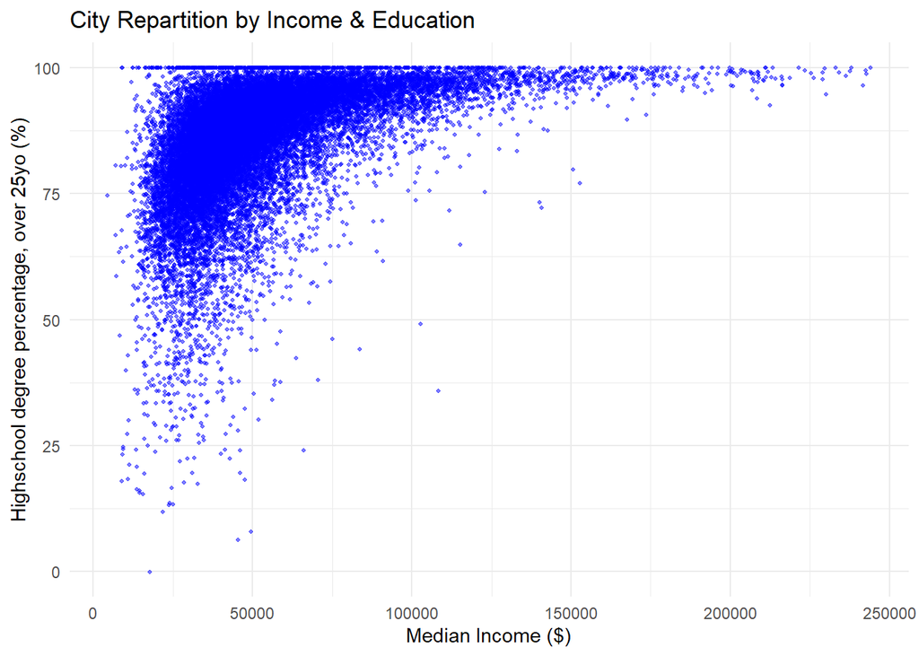

```r
all_cities <- df_temp1 %>%
  inner_join(df_temp2, by = c("city","state")) %>%
  select(state,city,education,income)%>%
  group_by(state,city) %>%
  mutate(count = 1) %>%
  unite("city",state:city, remove = TRUE)%>%
  drop_na(income,education)%>%
  filter(income != "(X)", education != "(X)",income != "-", education != "-")%>%
  mutate_at(c("education","income"),as.numeric)

all_cities %>%
  ggplot(aes(x=income,y=education))+
  geom_jitter(aes(size = count), alpha = 0.5,color = "blue") +
  scale_size(range = c(0, 1))+
  theme_minimal()+
  theme(legend.position = "none")+
  labs(x="Median Income ($)",y="Highschool degree percentage, over 25yo (%)", title = "City Repartition by Income & Education")
```

The last chart of this section is a zoom to interpret the difference between cities where shootings occurred versus all cities. It has been depleted of all annotations on purpose, all the description is available on the two previous charts.

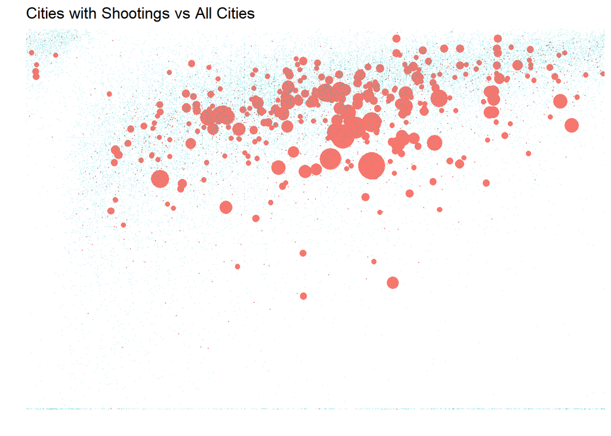

```r
# Combining both dataset to superpose the scatter plots

shooting_cities$id <- 'df1'
all_cities$id <- 'df2'
df <- rbind(shooting_cities,all_cities)

# Plot
df%>%
  mutate(alpha = ifelse(id == "df1",1,0.5))%>% # Creating an alpha column to distinguish among both dataset
ggplot(aes(x=income,y=education,color=factor(id)))+geom_jitter(aes(size = count,alpha = alpha))+
  scale_size(range = c(0, 10))+
  theme(axis.text.x=element_blank(),axis.text.y=element_blank(),panel.background = element_blank(),axis.ticks = element_blank())+
labs(x="", y="", title = "Cities with Shootings vs All Cities")+
  theme(legend.position = "none")
```

We can observe distinctly that income is not playing a role, however it seems that the education level is generally lower in the cities where the shootings occurred.